# Regresión polinómica

## Regresión cuadrática 2

Debido al resultado que indicó que había alta colinealidad lo que vamos a hacer ahora es centrar la variable de densidad para realizar el nuevo modelo. La función *scale* nos permite escalar la densidad considerando la media (hay dos formas por lo general. Primero es considerando un valor centrado tomándose en cuenta solamente la media y en el otro caso es tomar en cuenta también la desviación estándar obtenido para la primera regresión cuadrática

```r
# Primero vamos a estandardizar la densidad

# Sustraer la media, escala=falso significa no tomar en cuenta la desviación estándar
den_centrada<-scale(densidad, center=TRUE, scale=FALSE)

# Lo mismo hecho "a mano"
densidad-mean(densidad)
```

```
##  [1] -20 -20 -20 -10 -10 -10   0   0   0  10  10  10  20  20  20
```

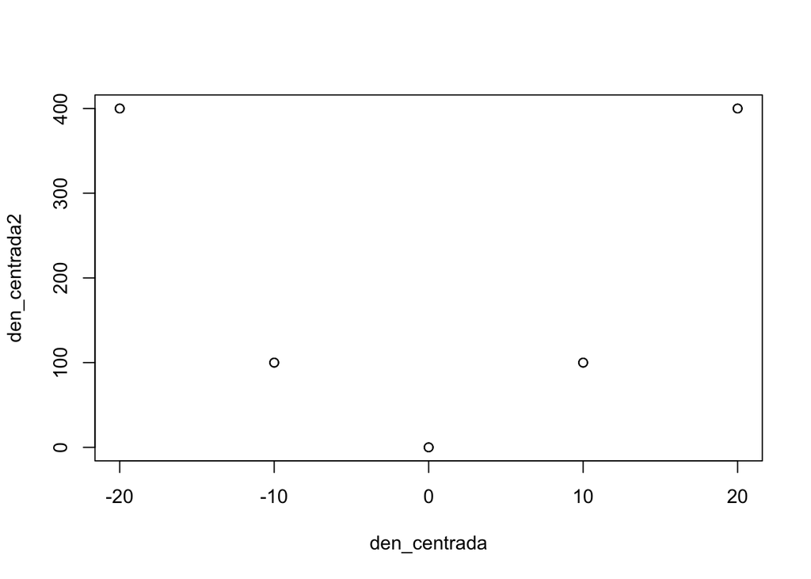

```r
# Crear la variable de den_centrada2
den_centrada2 <- den_centrada^2

plot(den_centrada, den_centrada2)
```

```r
# Regresión

modelo3<-lm(rendimiento~den_centrada+den_centrada2)
anova(modelo3)
```

|  | Df | Sum Sq | Mean Sq | F value | Pr(>F) |
| --- | --- | --- | --- | --- | --- |
| den_centrada | 1 | 43.20 | 43.2000000 | 52.46964 | 1.023598e-05 |
| den_centrada2 | 1 | 42.00 | 42.0000000 | 51.01215 | 1.176731e-05 |
| Residuals | 12 | 9.88 | 0.8233333 | NA | NA |

```r
summary(modelo3)
```

```
##
## Call:
## lm(formula = rendimiento ~ den_centrada + den_centrada2)
##
## Residuals:
##    Min     1Q Median     3Q    Max
##  -1.50  -0.50  -0.20   0.35   1.80
##
## Coefficients:
##               Estimate Std. Error t value Pr(>|t|)
## (Intercept)   18.40000    0.36511  50.396 2.44e-15 ***
## den_centrada   0.12000    0.01657   7.244 1.02e-05 ***
## den_centrada2 -0.01000    0.00140  -7.142 1.18e-05 ***
## ---
## Signif. codes:  0 '***' 0.001 '**' 0.01 '*' 0.05 '.' 0.1 ' ' 1
##
## Residual standard error: 0.9074 on 12 degrees of freedom
## Multiple R-squared:  0.8961, Adjusted R-squared:  0.8788
## F-statistic: 51.74 on 2 and 12 DF,  p-value: 1.259e-06
```

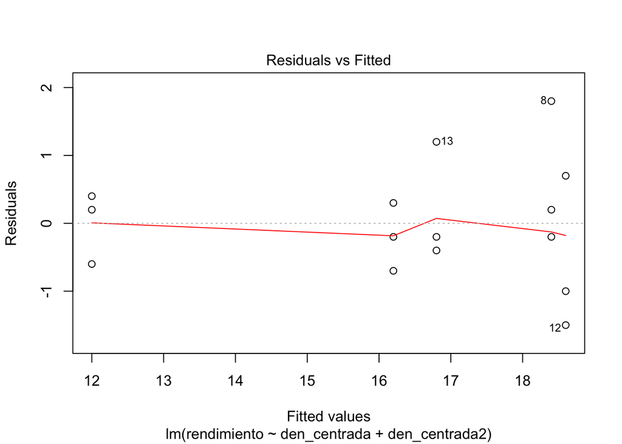

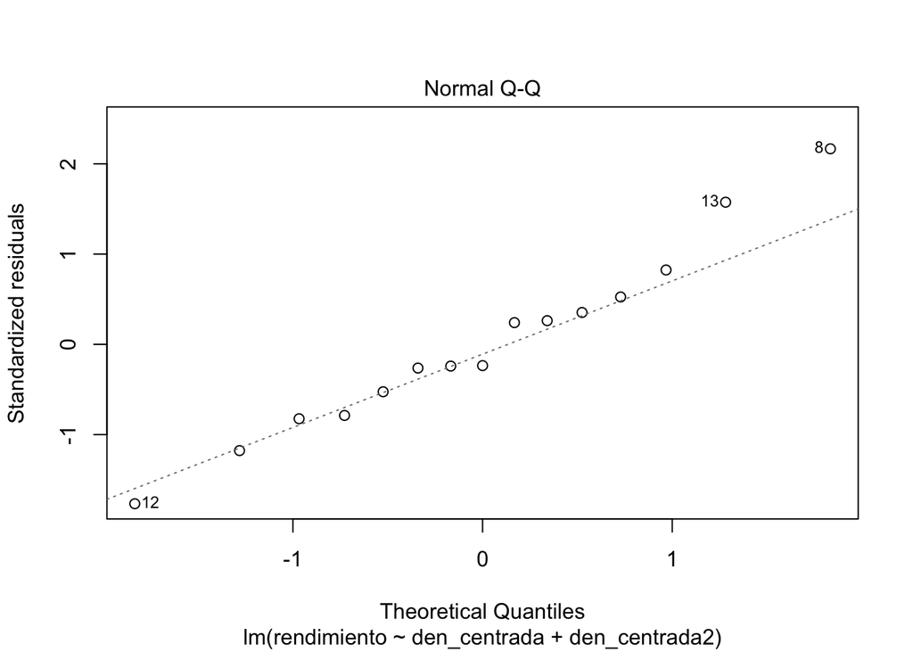

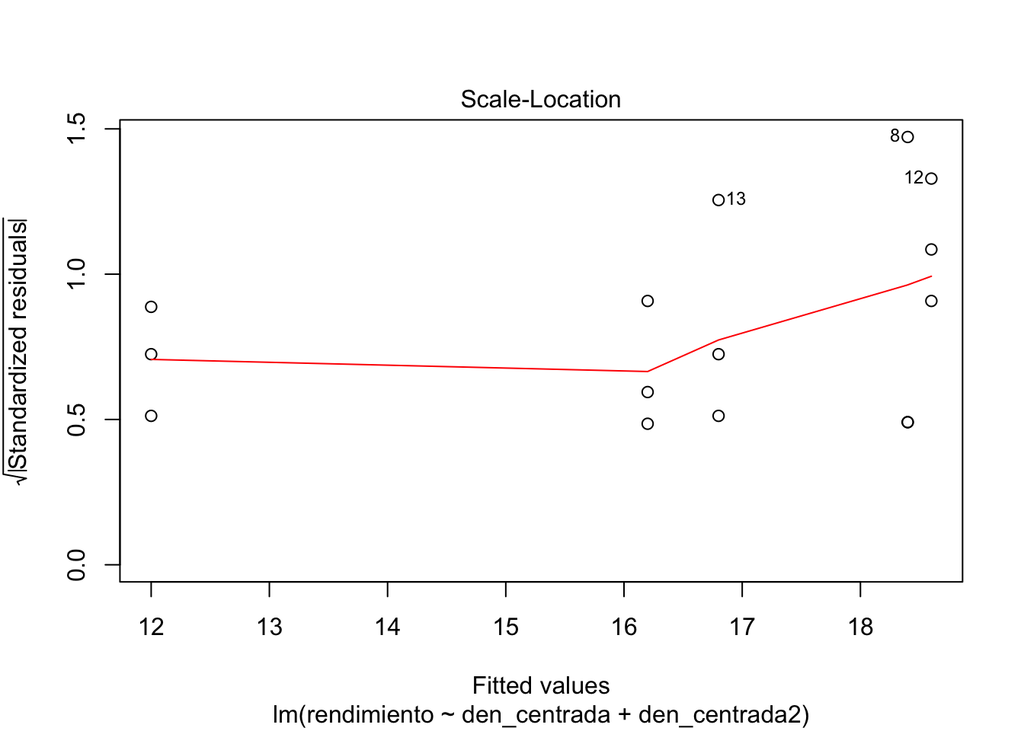

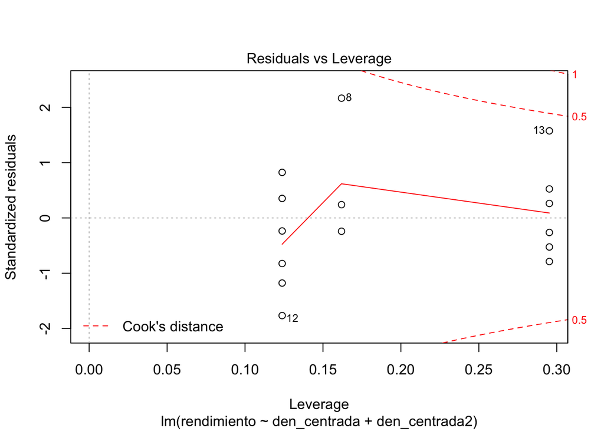

```r
# Supuestos
plot(modelo3)
```

```r
# Comparación entre el modelo original y el actualizado
anova(modelo1, modelo3)
```

|  | Res.Df | RSS | Df | Sum of Sq | F | Pr(>F) |
| --- | --- | --- | --- | --- | --- | --- |
| 1 | 13 | 51.88 | NA | NA | NA | NA |
| 2 | 12 | 9.88 | 1 | 42 | 51.01215 | 1.176731e-05 |

```r
# Colinealidad?
dffits(modelo3)
```

```
##           1           2           3           4           5           6
##  0.16317088 -0.50123382  0.32920738 -0.08494387 -0.30538465  0.12778710
##           7           8           9          10          11          12
##  0.10156307  1.16874641 -0.10156307 -0.45055886  0.30538465 -0.73883264
##          13          14          15
##  1.09610758 -0.32920738 -0.16317088
```

```r
dfbeta(modelo3)
```

```
##     (Intercept)  den_centrada den_centrada2
## 1  -0.008108108 -1.891892e-03  1.351351e-04
## 2   0.024324324  5.675676e-03 -4.054054e-04
## 3  -0.016216216 -3.783784e-03  2.702703e-04
## 4  -0.026086957  7.608696e-04  5.434783e-05
## 5  -0.091304348  2.663043e-03  1.902174e-04
## 6   0.039130435 -1.141304e-03 -8.152174e-05
## 7   0.038636364  7.647245e-20 -1.136364e-04
## 8   0.347727273  9.416246e-19 -1.022727e-03
## 9  -0.038636364  1.769001e-19  1.136364e-04
## 10 -0.130434783 -3.804348e-03  2.717391e-04
## 11  0.091304348  2.663043e-03 -1.902174e-04
## 12 -0.195652174 -5.706522e-03  4.076087e-04
## 13 -0.048648649  1.135135e-02  8.108108e-04
## 14  0.016216216 -3.783784e-03 -2.702703e-04
## 15  0.008108108 -1.891892e-03 -1.351351e-04
```

```r
covratio(modelo3)
```

```
##         1         2         3         4         5         6         7
## 1.8105775 1.5709359 1.7180496 1.4612786 1.2440860 1.4359881 1.5267335
##         8         9        10        11        12        13        14
## 0.3493908 1.5267335 1.0252651 1.2440860 0.6006431 0.9193090 1.7180496
##        15
## 1.8105775
```

```r
cooks.distance(modelo3)
```

```
##           1           2           3           4           5           6
## 0.009626105 0.086634944 0.038504420 0.002611680 0.031993085 0.005876281
##           7           8           9          10          11          12
## 0.003732810 0.302357630 0.003732810 0.065292011 0.031993085 0.146907024
##          13          14          15
## 0.346539778 0.038504420 0.009626105
```

```r
vif(modelo3) #Ahora el valor es de 1
```

```
##  den_centrada den_centrada2
##             1             1
```

## Comparación entre la forma de *densidad*

```r
cor(densidad, densidad2) #correlación que se considera muy alta = colinealidad
```

```
## [1] 0.9811049
```

```r
cor(den_centrada, den_centrada2) #ya no hay  correlación
```

```
##      [,1]
## [1,]    0
```

## Resumen y consideraciones

Lo que no se hizo en este ejercicio fue las predicciones para poder graficar la relación y el modelo. Se puede realizar este ejercicio fuera de la clase porque se aplican los mismos conceptos con el uso de la función *predict*.

Por último en este ejercicio se demostró que es importante tener presente que en nuestro ejemplo uno de los conceptos más importantes fue la demonstración de que el uso de un término cuadrático no se elimina necesariamente los asuntos de colinealidad. Es importante revisar cualquier *paquete* o *software* cuando hay necesidad de realizar este tipo de análisis. En el ejercicio que viene vamos a explorar modelos más complejos entonces los conceptos de colinealidad son importantes a considerar.